# Data Exploration and Visualization

# Cleaning Dataset Task

### Done by Group 3 members - Submitted on 12-Apr-2023

### Mohammad Awad

### Alaa *

### Anas *

### Ibrahim *

## Loading Libraries

```r
library(tidyverse)
```

```r
library(ggplot2)
library(ggthemes)
library(tidyr)
```

## Importing data

```r
df <- read_csv('Project Data - Uncleaned.csv')
glimpse(df)
```

```
## Rows: 1,211
## Columns: 17
## $ ID                    <dbl> 1, 2, 3, 4, 5, 6, 7, 8, 9, 10, 11, 12, 13, 14, 1~
## $ Region                <chr> "WA", "EA", "EA", "WZ", "EA", "WZ", "EA", "SZ", ~
## $ Age                   <dbl> 36, 48, 46, 65, 48, 46, 58, 65, 39, 47, 69, 68, ~
## $ BMI                   <dbl> 27.9, 30.2, 28.6, 34.9, 29.2, 24.9, 31.6, 25.1, ~
## $ Gender                <chr> "Female", "Female", "Female", "Female", "Female"~
## $ Marital_Status        <chr> "Married", "Married", "Married", "Married", "Mar~
## $ Education             <dbl> 2, 1, 1, 1, 2, 1, 2, 1, 1, 2, 1, 1, 2, 3, 2, 2, ~
## $ Employment            <chr> "Yes", "No", "No", "No", "Yes", "No", "Yes", "No~
## $ HH_Income             <dbl> 3, 1, 1, 2, 2, 2, 2, 1, 2, 4, 3, 2, 2, 1, 1, 1, ~
## $ Rent                  <chr> "Yes", "Yes", "Yes", "Yes", "Yes", "Yes", "Yes",~
## $ Loans                 <chr> "No", "No", "No", "Yes", "No", "Yes", "No", "No"~
## $ Smoking               <chr> "Yes", "No", "Yes", "Yes", "Yes", "No", "Yes", "~
## $ Diabetes_Duration     <dbl> 43, 97, 68, 119, 61, 98, 42, 154, 35, 109, 182, ~
## $ Hypertension_category <chr> "Normal", "First-Grade", "First-Grade", "Second-~
## $ CVD                   <dbl> 0, 1, 1, 0, 1, 0, 0, 1, 0, 1, 1, 0, 0, 0, 1, 1, ~
## $ HbA1c                 <dbl> 7.2, 8.9, 9.8, 9.7, 10.4, 8.7, 8.9, 6.8, 9.2, 8.~
## $ Uncontrolled          <dbl> 0, 0, 1, 1, 1, 0, 0, 0, 1, 0, 0, 0, 0, 0, 0, 0, ~
```

## Convert to factor the categorical variables

```r
df$Region <- as.factor(df$Region)
df$Gender <- as.factor(df$Gender)
df$Marital_Status <- as.factor(df$Marital_Status)
df$Education <- factor(df$Education, levels = c("1","2","3"), ordered = TRUE)
df$Employment <- as.factor(df$Employment)

df$HH_Income <- factor(df$HH_Income, levels = c("1","2","3","4","5"), ordered = TRUE)

df$Rent <- as.factor(df$Rent)
df$Loans <- as.factor(df$Loans)
df$Smoking <- as.factor(df$Smoking)
df$Hypertension_category <- as.factor(df$Hypertension_category)
df$CVD <- as.factor(df$CVD)
df$Uncontrolled <- as.factor(df$Uncontrolled)

glimpse(df)
```

```
## Rows: 1,211
## Columns: 17
## $ ID                    <dbl> 1, 2, 3, 4, 5, 6, 7, 8, 9, 10, 11, 12, 13, 14, 1~
## $ Region                <fct> WA, EA, EA, WZ, EA, WZ, EA, SZ, WZ, EA, SZ, SZ, ~
## $ Age                   <dbl> 36, 48, 46, 65, 48, 46, 58, 65, 39, 47, 69, 68, ~
## $ BMI                   <dbl> 27.9, 30.2, 28.6, 34.9, 29.2, 24.9, 31.6, 25.1, ~
## $ Gender                <fct> Female, Female, Female, Female, Female, Female, ~
## $ Marital_Status        <fct> Married, Married, Married, Married, Married, Mar~
## $ Education             <ord> 2, 1, 1, 1, 2, 1, 2, 1, 1, 2, 1, 1, 2, 3, 2, 2, ~
## $ Employment            <fct> Yes, No, No, No, Yes, No, Yes, No, No, Yes, No, ~
## $ HH_Income             <ord> 3, 1, 1, 2, 2, 2, 2, 1, 2, 4, 3, 2, 2, 1, 1, 1, ~
## $ Rent                  <fct> Yes, Yes, Yes, Yes, Yes, Yes, Yes, Yes, No, No, ~
## $ Loans                 <fct> No, No, No, Yes, No, Yes, No, No, Yes, No, No, N~
## $ Smoking               <fct> Yes, No, Yes, Yes, Yes, No, Yes, Yes, No, Yes, N~
## $ Diabetes_Duration     <dbl> 43, 97, 68, 119, 61, 98, 42, 154, 35, 109, 182, ~
## $ Hypertension_category <fct> Normal, First-Grade, First-Grade, Second-Grade, ~
## $ CVD                   <fct> 0, 1, 1, 0, 1, 0, 0, 1, 0, 1, 1, 0, 0, 0, 1, 1, ~
## $ HbA1c                 <dbl> 7.2, 8.9, 9.8, 9.7, 10.4, 8.7, 8.9, 6.8, 9.2, 8.~
## $ Uncontrolled          <fct> 0, 0, 1, 1, 1, 0, 0, 0, 1, 0, 0, 0, 0, 0, 0, 0, ~
```

## Checking that there is no duplicate lines

```r
nrow(df) == nrow(distinct(df))
```

```
## [1] TRUE
```

## Starting with summary for all features

```r
summary(df)
```

```
##        ID         Region        Age             BMI            Gender
##  Min.   :   1.0   EA:416   Min.   : 3.60   Min.   :  2.20   Female:667
##  1st Qu.: 303.5   SZ:393   1st Qu.:50.00   1st Qu.: 25.90   Male  :544
##  Median : 606.0   WA:145   Median :56.00   Median : 28.30
##  Mean   : 606.0   WZ:257   Mean   :54.71   Mean   : 29.32
##  3rd Qu.: 908.5            3rd Qu.:59.00   3rd Qu.: 31.50
##  Max.   :1211.0            Max.   :79.00   Max.   :254.00
##   Marital_Status Education  Employment HH_Income  Rent     Loans     Smoking
##  Divorced:135    1   :486   No :738    1:120     No :413   No :759   No :731
##  M       :  1    2   :578   Yes:473    2:650     Yes:798   Yes:452   Yes:480
##  Married :962    3   :145              3:211
##  Single  : 61    NA's:  2              4:181
##  Widowed : 52                          5: 49
##
##  Diabetes_Duration      Hypertension_category CVD         HbA1c
##  Min.   :  6.00    First-Grade     :376       0:794   Min.   : 5.90
##  1st Qu.: 37.00    Normal          :232       1:417   1st Qu.: 7.40
##  Median : 62.00    Pre-hypertention:479               Median : 8.30
##  Mean   : 65.97    Prehypertention :  1               Mean   : 8.43
##  3rd Qu.: 85.00    Second-Grade    :110               3rd Qu.: 9.20
##  Max.   :860.00    Third-Grade     : 13               Max.   :13.20
##  Uncontrolled
##  0:859
##  1:352
##
##
##
##
```

## From the summary below is noted:

#### - Age has a min value of 3.6 while metadata mention adults.

#### - BMI has a min value of 2.2 and the maximum of 254 both are beyond normal range.

#### - For marital status most of the data showing as Maried there is 1 M category , will convert it to Maried.

#### - Education has 2 NA’s values which they actually refer to as 4 in the uncleaned data.

#### - There is 1 record that should be called Prehypertention to be Pre-hypertention.

#### - The Diabetes_Duration has a max vaule of 860 which is 71.667, we need to check and compare it against age of that record, or if any other records that are greater than Age.

### Below table is a comparison between the metadata provided in the TOR and the summary generated using R.

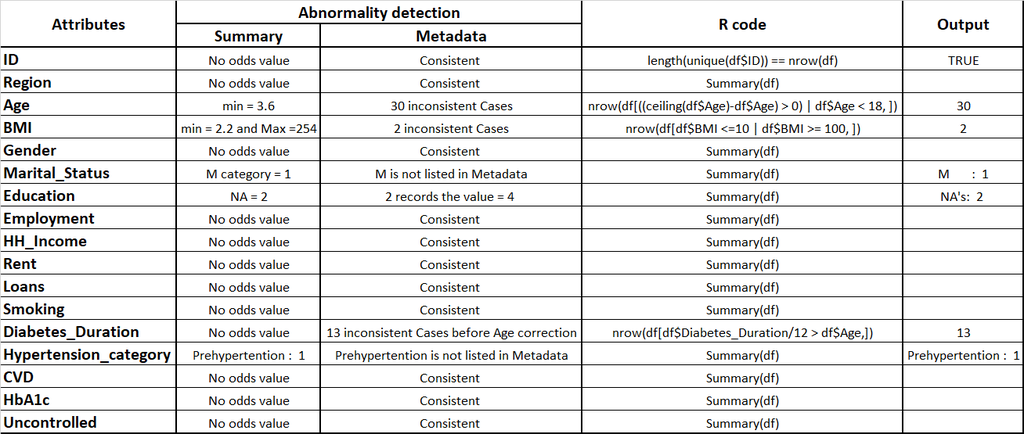

```r
knitr::include_graphics("SummaryvsMetadata.png")
```

## The following changes were made after checking with Dr. Osama regarding the correct approach to deal with the mentioned issues.

## To print the lines that have NA values in the education , we can fill them with the value of category 3

```r
df[!complete.cases(df), ]
```

```
## # A tibble: 2 x 17
##      ID Region   Age   BMI Gender Marital_Status Education Employment HH_Income
##   <dbl> <fct>  <dbl> <dbl> <fct>  <fct>          <ord>     <fct>      <ord>
## 1  1032 WZ        47  26.7 Male   Married        <NA>      No         2
## 2  1036 WZ        52  23.4 Male   Married        <NA>      Yes        3
## # i 8 more variables: Rent <fct>, Loans <fct>, Smoking <fct>,
## #   Diabetes_Duration <dbl>, Hypertension_category <fct>, CVD <fct>,
## #   HbA1c <dbl>, Uncontrolled <fct>
```

```r
df <- df %>%
  replace_na( list(Education = "3"))
summary(df$Education)
```

```
##   1   2   3
## 486 578 147
```

## To correct the Marital status of the category M to be Married

```r
df$Marital_Status <- gsub("M", "Married", df$Marital_Status)
df$Marital_Status <- gsub("Marriedarried", "Married", df$Marital_Status)
df$Marital_Status <- as.factor(df$Marital_Status)
summary(df$Marital_Status)
```

```
## Divorced  Married   Single  Widowed
##      135      963       61       52
```

## To correct the Hypertension_category of Prehypertention to Pre-hypertention and then transforming it into ordinal categories

```r
df$Hypertension_category <- gsub("Prehypertention", "Pre-hypertention", df$Hypertension_category)
df$Hypertension_category <- factor(df$Hypertension_category, levels= c("Normal", "Pre-hypertention", "First-Grade", "Second-Grade", "Third-Grade"), ordered=TRUE)
summary(df$Hypertension_category)
```

```
##           Normal Pre-hypertention      First-Grade     Second-Grade
##              232              480              376              110
##      Third-Grade
##               13
```

## To correct the BMI values of 2.2 and 254

```r
df[(df$BMI > 56 | df$BMI < 10),] # to get the ID of those records
```

```
## # A tibble: 2 x 17
##      ID Region   Age   BMI Gender Marital_Status Education Employment HH_Income
##   <dbl> <fct>  <dbl> <dbl> <fct>  <fct>          <ord>     <fct>      <ord>
## 1   207 WZ        35 254   Male   Married        2         Yes        2
## 2   884 WZ        55   2.2 Male   Married        1         Yes        1
## # i 8 more variables: Rent <fct>, Loans <fct>, Smoking <fct>,
## #   Diabetes_Duration <dbl>, Hypertension_category <ord>, CVD <fct>,
## #   HbA1c <dbl>, Uncontrolled <fct>
```

```r
df$BMI[df$ID == 207] <- df$BMI[df$ID == 207]/10
df$BMI[df$ID == 207]
```

```
## [1] 25.4
```

```r
df$BMI[df$ID == 884] <- df$BMI[df$ID == 884]*10
df$BMI[df$ID == 884]
```

```
## [1] 22
```

```r
summary(df$BMI)
```

```
##    Min. 1st Qu.  Median    Mean 3rd Qu.    Max.
##   18.20   25.90   28.30   29.15   31.50   55.60
```

## To correct the Age values that are less 18 (since the data is mentioning adults)

```r
df[df$Age <= 20,]
```

```
## # A tibble: 30 x 17
##       ID Region   Age   BMI Gender Marital_Status Education Employment HH_Income
##    <dbl> <fct>  <dbl> <dbl> <fct>  <fct>          <ord>     <fct>      <ord>
##  1    42 EA       6.3  23.7 Female Married        2         No         1
##  2    43 EA       6.8  28.7 Male   Married        1         No         1
##  3    44 SZ       6.9  26.8 Female Married        1         No         2
##  4    45 EA       4.5  34.6 Male   Divorced       2         No         2
##  5    46 EA       5.3  26.9 Female Married        1         Yes        3
##  6    47 EA       4.8  25.7 Male   Married        2         Yes        2
##  7    48 WA       5.5  34.8 Female Divorced       2         No         2
##  8    49 WA       3.9  42.9 Female Married        2         No         4
##  9    50 SZ       5.8  32.8 Female Married        1         No         4
## 10    51 EA       4.7  42.9 Male   Married        2         No         2
## # i 20 more rows
## # i 8 more variables: Rent <fct>, Loans <fct>, Smoking <fct>,
## #   Diabetes_Duration <dbl>, Hypertension_category <ord>, CVD <fct>,
## #   HbA1c <dbl>, Uncontrolled <fct>
```

```r
df$Age <- ifelse(df$Age < 20, df$Age * 10, df$Age)
summary(df$Age)
```

```
##    Min. 1st Qu.  Median    Mean 3rd Qu.    Max.
##   35.00   50.00   56.00   55.91   59.00   79.00
```

## The last thing we want to check is to ensure that Diabetes_Duration is less than the Age of the patience as we have a max value of 860 which is in years 71.67

```r
df$Diabetes_Duration_years <- df$Diabetes_Duration/12.0
summary(df[,c("Age", "Diabetes_Duration_years")])
```

```
##       Age        Diabetes_Duration_years
##  Min.   :35.00   Min.   : 0.500
##  1st Qu.:50.00   1st Qu.: 3.083
##  Median :56.00   Median : 5.167
##  Mean   :55.91   Mean   : 5.497
##  3rd Qu.:59.00   3rd Qu.: 7.083
##  Max.   :79.00   Max.   :71.667
```

```r
df[df$Diabetes_Duration_years >= df$Age, ]
```

```
## # A tibble: 1 x 18
##      ID Region   Age   BMI Gender Marital_Status Education Employment HH_Income
##   <dbl> <fct>  <dbl> <dbl> <fct>  <fct>          <ord>     <fct>      <ord>
## 1   533 WA        59  23.3 Female Married        2         Yes        4
## # i 9 more variables: Rent <fct>, Loans <fct>, Smoking <fct>,
## #   Diabetes_Duration <dbl>, Hypertension_category <ord>, CVD <fct>,
## #   HbA1c <dbl>, Uncontrolled <fct>, Diabetes_Duration_years <dbl>
```

## From the code above we can see that the Diabetes_Duration = 71.667 years and the person age is 59 which is incorrect, this value should be divided by 10

### The id = 533

```r
df$Diabetes_Duration[df$ID == 533] <- df$Diabetes_Duration[df$ID == 533]/10
df[df$ID == 533,]
```

```
## # A tibble: 1 x 18
##      ID Region   Age   BMI Gender Marital_Status Education Employment HH_Income
##   <dbl> <fct>  <dbl> <dbl> <fct>  <fct>          <ord>     <fct>      <ord>
## 1   533 WA        59  23.3 Female Married        2         Yes        4
## # i 9 more variables: Rent <fct>, Loans <fct>, Smoking <fct>,
## #   Diabetes_Duration <dbl>, Hypertension_category <ord>, CVD <fct>,
## #   HbA1c <dbl>, Uncontrolled <fct>, Diabetes_Duration_years <dbl>
```

## Data is now ready, just dropping the columns created and we can save it into CSV

```r
df <- subset(df, select = -Diabetes_Duration_years)
write_csv(df, "Project Data-cleand-group3.csv")
```